# **Graph**

*Graph* adalah jaringan yang terdiri dari node (atau *vertex*, V) yang terhubung dengan edge (atau *arc*, E). Graph dapat didefinisikan sebagai sepasang set dari $G=(V,E)$, di mana V adalah vertex/node/titik, dan E adalah edge/arc atau set node pasangannya.  
Sebagai contoh, set node dan set pasangannya  
𝐸 = {{𝑎, 𝑏}, {𝑏, 𝑐}, {𝑐, 𝑑}, {𝑑, 𝑎}}.  
Gambar berikut adalah ilustrasi dari Graph.

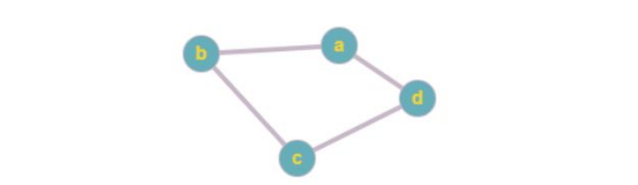

**Gambar 1. Graph**

Berikut akan dijelaskan mengenai :

1. Istilah dalam Graph
2. Jenis-Jenis Graph

## **Istilah dalam Graph**

Beberapa istilah yang terdapat dalam *graph*, antara lain:

- **Vertex (V)** Bagian paling dasar dari grafik atau yang disebut juga sebagai node/titik.
- **Edge (E)** Bagian dari graph yang menghubungkan 2 vertex/node/titik.
- **Weight (W)** Sebuah nilai dalam graph atau yang menunjukan biaya yang dibutuhkan untuk berpindah dari satu titik ke titik yang lain.
- **Path** Serangkaian vertex yang berbeda-beda yang berdekatan dihubungkan oleh edge dan berturut-turut dari vertex satu ke vertex berikutnya.

Gambar 2 berikut menunjukan beberapa istilah dalam graph.

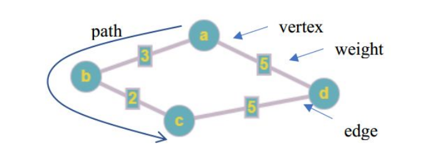

**Gambar 2. Istilah dalam Graph**

Kembali ke Menu Awal

## **Jenis Graph**

Bentuk dari graph dibedakan menjadi beberapa jenis, antara lain: *Undirected Graph, Directed Graph, Weigthed Graph, Unweigthed Graph, Cyle Graph, Conected Graph, Unconeted Graph, dan Complete Graph*

### **Undirected Graph**

Sebuah graph yang ujung – ujung dari edge tidak memiliki arah (atau tidak memiliki mata panah), dimana setiap ujung dari edge berlaku dua arah.

Misalkan:  
{$a$, $b$} Arah bisa dari $a$ ke $b$, atau $b$ ke $a$  
$a-b$ terdiri dari {$a$, $b$} atau {$b$,$a$}

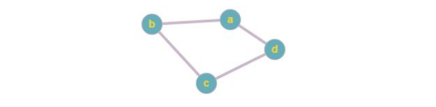

**Gambar 3. Undirected Graph**  
Maka notasi graph dari Gambar 3 adalah  
$G=(V,E)$  
$V$= {$a,b,c,d$}  
$E$ = {{$a,b$},{$a,d$},{$b,c$},{$d,c$}}

### **Directed Graph (Diagraph)**

Sebuah *graph* yang ujung – ujung dari *edge* memiliki arah, dimana setiap ujung dari *edge* dalam *Digraph* memiliki anak panah yang mengarah ke vertex tertentu.

Misalkan  
{$a,b$} Arah dari $a$ ke $b$  
$𝑎 → 𝑏$ terdiri dari {$a,b$}

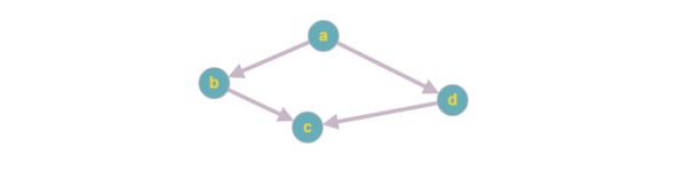

**Gambar 4. Directed Graph**  
Maka notasi graph dari Gambar 4 adalah

$G=(V,E)$  
$V$= {$a,b,c,d$}  
$E$ = {{$a,b$},{$a,d$},{$b,c$},{$d,c$}}

### **Weighted Graph dan Unweighted Graph**

*Weigthed Graph* Sebuah graph dimana setiap edge memiliki nilai. Nilai tersebut adalah representasi dari bobot/biaya/weight dari edge tersebut. Bobot ini boleh lebih dari satu, semisal jarak antar kota, jumlah kendaraan yang melintasi kota tersebut, dll.

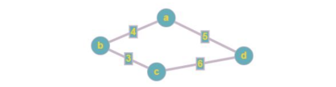

**Gambar 5. Weighted Graph**

Maka notasi graph dari Gambar 5 adalah  
$G=(V,E)$  
$V$= {$a,b,c,d$}  
$E$ = {{$a,b,4$},{$a,d,5$},{$b,c,3$},{$d,c,6$}}

Jumlah bobot dalam *weighted graph* adalah sejumlah nilai untuk semua *edge* dalam suatu *path*, seperti *path* dari $a$ ke $c$ maka jumlah bobotnya adalah 7.  
Gambar 4 juga disebut *unweighted graph* maka jumlah bobotnya dihitung dari jumlahnya *edge*. Jika *path* dari a ke c maka bobotnya adalah 2.

### **Cycle Graph**

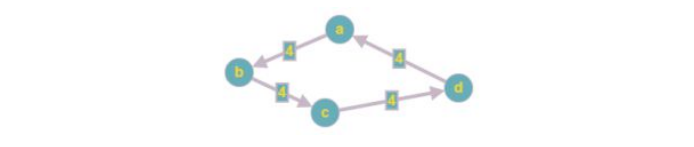

**Gambar 6. Cycle Graph**

### **Connected Graph dan Disconnected Graph**

*Connected Graph *adalah sebuah *graph* dimana setiap vertex terhubung satu dengan lainnya, dalam *graph* tersebut tidak ada vertex yang tidak terhubung. Sedangkan *disconnected graph* jika salah satu vertex tidak terhubung dengan vertex lainnya, atau dapat dikatakan tidak ada jalur menuju vertex tersebut.  
Gambar 7a adalah Connected Graph dan gambar 7b adalah *disconnected Graph.*

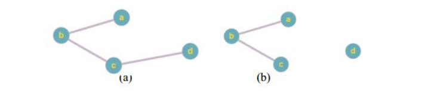

**Gambar 7. (a)Connected Graph (b)Disconnected Graph**

Kembali ke Menu Awal